# INFO-F-305 - TP 3

# Dessin qualitiatif - Portrait de phase II

### Jacopo De Stefani - **jdestefa@ulb.ac.be**

# Système linéaire, regulier, à dimensions finies - Th 5.1

$\begin{cases} \dot{\mathbf{X}}(t) & = \mathbf{A}(t)\mathbf{X}(t) + \mathbf{B}(t)\mathbf{U}(t) \\ \mathbf{Y}(t) & = \mathbf{C}(t)\mathbf{X}(t) \\ \end{cases}$

où $\mathbf{A}(\cdot),\mathbf{B}(\cdot),\mathbf{C}(\cdot)$ sont des matrices continues en $T$.

Si on considère le mouvement libre (c-à-d $\mathbf{U}(t) = 0$ $\forall t$), et on se concentre sur l'état, avec $\mathbf{A}(t)$ constante:

$\dot{\mathbf{X}}(t) = \mathbf{A}\mathbf{X}(t)$

# Rappels Théoriques - Système du second ordre

$\dot{\mathbf{X}}(t) = \mathbf{A}\mathbf{X}(t)$

$\begin{bmatrix}\dot{x_{1}}\\ \dot{x_{2}}\end{bmatrix}=\begin{bmatrix}a_{11} & a_{12}\\ a_{21} & a_{22}\end{bmatrix}\begin{bmatrix}x_{1}\\ x_{2}\end{bmatrix}$

### Equation caractéristique

$\det(A-\lambda I) = \lambda^{2}-\tau\lambda+\Delta=0$

$\lambda_{1,2} = \frac{\tau \pm \sqrt{\tau^2 - 4 \Delta}}{2}$

où:

- $\tau=a_{11}+a_{22}=tr(A)$
- $\Delta=a_{11}a_{22}-a_{12}a_{21}=\det(A)$

# Mouvement et trajectoire

### Mouvement

Ensemble des paires $\{(t,x(t))\}$ pour un système $\mathbf{X}(t)=\varphi(t,t_0,\mathbf{X_{t_0}},u(\cdot))$

### Trajectoire

Ensemble des valeurs $\{x(t)\}$ pour $t\geq t_0$ pour un système $\mathbf{X}(t)=\varphi(t,t_0,\mathbf{X_{t_0}},u(\cdot))$

### Calcul d'une trajectoire

1. Calcul équation solution générale de $\dot{\mathbf{X}}(t) = \mathbf{A}\mathbf{X}(t)$
2. Détermination $c_1$ et $c_2$ dans la solution générale en fonction de $\mathbf{X}(0)$
3. Calcul de la trajectoire pour différent valeurs de $t$

# Stabilité

### Stabilité asymptotique

Si le mouvement libre du système (c-à-d en absence d'entrée $\mathbf{U}(t)$) tends vers l'origine pour chaque valeur de la condition initiale.

### Stabilité simple

Si le mouvement libre du système (c-à-d en absence d'entrée $\mathbf{U}(t)$) est limité pour chaque valeur de la condition initiale.

### Instabilité

S'il existe au moins une condition initiale telle que le mouvement libre du système (c-à-d en absence d'entrée $\mathbf{U}(t)$) ne soit pas limité.

# Stabilité et valeurs propres

### Stabilité asymptotique - Th 5.3

Un système $\dot{\mathbf{X}}(t) = \mathbf{A}\mathbf{X}(t)$ est asymptotiquement stable si la partie réelle de tous les valeurs propres de A est negative.

### Stabilité simple - Th 5.4

Un système $\dot{\mathbf{X}}(t) = \mathbf{A}\mathbf{X}(t)$ est (simplement) stable si la partie réelle de tous les valeurs propres de A est negative ou nulle et celles ayant partie réelle nulle ont une multiplicité égale à 1.

### Instabilité - Th 5.5

Un système $\dot{\mathbf{X}}(t) = \mathbf{A}\mathbf{X}(t)$ est instable s'il existe soit une valeur propre de A avec partie réelle positive soit une valeur propre ayant partie réelle nulle et une multiplicité supérieure à 1.

# Points d'équilibre

### Definition

Un point d’équilibre est un point où la trajectoire coincide avec la condition initiale.

- Si $\det(\mathbf{A}) \neq 0$ alors le seul état d’équilibre est (0, 0) et le système corréspondant est dit *simple*
- Si $\det(\mathbf{A}) = 0$ alors il existe plusieurs état d'équilibre et le système corréspondant est dit *non simple*

# Cas 1 - Racines réelles et distinctes - $\lambda_1,\lambda_2$

### Solution générale - Théoreme 5.11

$\mathbf{X}(t) = C_1 \mathbf{X}^{(1)}(t) + C_2 \mathbf{X}^{(2)}(t) $

### Solution particulières

$\mathbf{X}^{(1)}(t) = e^{\lambda_1 t} \mathbf{v_1} $

$\mathbf{X}^{(2)}(t) = e^{\lambda_2 t} \mathbf{v_2} $

### Exemple

$\mathbf{\dot{x}}=\begin{bmatrix}1 & 3\\ 3 & 1\end{bmatrix}\mathbf{x}$

```matlab
pkg load symbolic

A = [1 3;3 1]
syms x1(t) x2(t);
ode_sys = [diff(x1(t),t) == A(1,1)*x1(t) + A(1,2)*x2(t);  diff(x2(t),t) == A(2,1)*x1(t) + A(2,2)*x2(t)]
solutions = dsolve(ode_sys);
solutions{1}
solutions{2}
```

```
A =

   1   3
   3   1

ode_sys = (sym 2x1 matrix)

  [d                          ]
  [--(x1(t)) = x1(t) + 3*x2(t)]
  [dt                         ]
  [                           ]
  [d                          ]
  [--(x2(t)) = 3*x1(t) + x2(t)]
  [dt                         ]

ans = (sym)

                4*t         -2*t
  x1(t) = 3*C1*e    + 3*C2*e

ans = (sym)

                4*t         -2*t
  x2(t) = 3*C1*e    - 3*C2*e
```

# Stabilité - - Racines réelles et distinctes - $\lambda_1,\lambda_2$

### Noeud stable

Si les valeurs propres de $\mathbf{A}$ sont réelles et négatives.

### Noeud instable

Si les valeurs propres de $\mathbf{A}$ sont réelles et positive.

### Selle

Si les valeurs propres de $\mathbf{A}$ sont réelles et ayant signe discorde.

# Système non simple

Considérons le cas où $\det(A) = \lambda_1\lambda_2 = 0$ et la valeur propre $\lambda_2 \neq 0$.

Tous les états qui appartiennent à la droite $a_{11}x_1 + a_{12}x_2 = 0$ sont des états d’équilibre. Aussi, toutes les trajectoires sont des droites parallèles à la droite $v_2$.

Deux configurations sont possibles:

- $0 = \lambda_1 > \lambda_2$ : ceci implique que tous les états d’équilibre sont stables.
- $ 0 = \lambda_1 < \lambda_2$: ceci implique que tous les états d’équilibre sont instables.

# Cas 2 - Racines réelles et multiples - $\lambda=\lambda_1=\lambda_2$

### Solution générale - Théoreme 5.11

$\mathbf{X}(t) = C_1 \mathbf{X}^{(1)}(t) + C_2 \mathbf{X}^{(2)}(t) $

### Solution particulières

$\mathbf{X}^{(1)}(t) = e^{\lambda t} \mathbf{v_1} $

$\mathbf{X}^{(2)}(t) = e^{\lambda t} (\mathbf{v_2} + t\mathbf{v_1}) $

### Exemple

$\mathbf{\dot{x}}=\begin{bmatrix}3 & -4\\ 1 & -1\end{bmatrix}\mathbf{x}$

```matlab
pkg load symbolic

A = [3 -4;1 -1]
syms x1(t) x2(t);
ode_sys = [diff(x1(t),t) == A(1,1)*x1(t) + A(1,2)*x2(t);  diff(x2(t),t) == A(2,1)*x1(t) + A(2,2)*x2(t)]
solutions = dsolve(ode_sys);
solutions{1}
solutions{2}
```

```
A =

   3  -4
   1  -1

ode_sys = (sym 2x1 matrix)

  [d                            ]
  [--(x1(t)) = 3*x1(t) - 4*x2(t)]
  [dt                           ]
  [                             ]
  [  d                          ]
  [  --(x2(t)) = x1(t) - x2(t)  ]
  [  dt                         ]

ans = (sym)

                                   t
  x1(t) = (-4*C1 + C2*(-4*t - 2))*e

ans = (sym)

                            t
  x2(t) = (-2*C1 - 2*C2*t)*e
```

# Stabilité - Racines réelles et multiples - $\lambda=\lambda_1=\lambda_2$

### Systéme simple - $\lambda_1 = \lambda_2 = \lambda \neq 0$

- A diagonalisable - : Tous les vecteurs sont vecteurs propres. Chaque droite qui passe par l’origine est une trajectoire. Si $\lambda < 0(> 0)$ nous avons la (in)stabilité asymptotique. L’origine est dénommée **noeud singulier**.
- A non diagonalisable: il existe un seul vecteur propre et donc seul une droite qui contient une trajectoire. L’origine est dénommée **noeud dégénéré**.

### Systéme non simple - $\lambda_1 = \lambda_2 = \lambda = 0$

- Il y a une infinité de points d’équilibres instables (multiplicité plus grande que 1) et toutes les trajectoires se trouvent sur des droites parallèles.

# Cas 3 - Racines complexes et conjuguées - $\lambda_{1,2} = \alpha \pm i\beta$

### Solution générale - Théoreme 5.11

$\mathbf{X}(t) = C_1 \mathbf{X}^{(1)}(t) + C_2 \mathbf{X}^{(2)}(t) $

### Solution particulières - $\mathbf{v_{1,2}} = \mathbf{u} + i \mathbf{v}$

$\mathbf{X}^{(1)}(t) = e^{\alpha t} (\cos(\beta t)\mathbf{u} - \sin(\beta t)\mathbf{v} ) $

$\mathbf{X}^{(2)}(t) = e^{\alpha t} (\sin(\beta t)\mathbf{u} + \cos(\beta t)\mathbf{v}) $

### Exemple

$\mathbf{\dot{x}}=\begin{bmatrix}0 & 4\\ -1 & 0\end{bmatrix}\mathbf{x}$

```matlab
pkg load symbolic

A = [0 4;-1 0]
syms x1(t) x2(t);
ode_sys = [diff(x1(t),t) == A(1,1)*x1(t) + A(1,2)*x2(t);  diff(x2(t),t) == A(2,1)*x1(t) + A(2,2)*x2(t)]
solutions = dsolve(ode_sys);
solutions{1}
solutions{2}
```

```
A =

   0   4
  -1   0

ode_sys = (sym 2x1 matrix)

  [d                  ]
  [--(x1(t)) = 4*x2(t)]
  [dt                 ]
  [                   ]
  [d                  ]
  [--(x2(t)) = -x1(t) ]
  [dt                 ]

ans = (sym) x1(t) = 4*C1*cos(2*t) + 4*C2*sin(2*t)
ans = (sym) x2(t) = -2*C1*sin(2*t) + 2*C2*cos(2*t)
```

# Stabilité - Racines complexes et conjuguées - $\lambda_{1,2} = \alpha \pm i\beta$

### Centre

- $\alpha = 0$: Les trajectoires sont des ellipses fermées avec période $T = \frac{2\pi}{b}$. L’origine est dit un **centre**.

### Foyer stable

- $\alpha < 0$: Le système est asymptotiquement stable et les trajectoires convergent vers l’origine en suivant des spirales.

### Foyer instable

- $\alpha > 0$: Le système est instable et les trajectoires s’éloignent de l’origine en suivant des spirales.

# Exercice 1 - Système non simple

$ \mathbf{A} = \begin{bmatrix} 0 & 1 \\ 0 & 1 \end{bmatrix} $

1. Calculer les valeurs propres et vecteurs propres et en déduire le type du système
2. Vérifier le lien entre la trace et le déterminant de la matrice
3. Dessiner les vecteurs vitesse pour les points suivants (en normalisant leurs tailles):
   - $(0,1),(0,-1),(1,0),(-1,0)$

```matlab
# 1. Calcul valeur propres et vecteurs propres
A = [0 1; 0 1]
[V,L] = eig(A)
```

```
A =

   0   1
   0   1

V =

   1.00000   0.70711
   0.00000   0.70711

L =

Diagonal Matrix

   0   0
   0   1
```

```matlab
printf("Tr(A) = %d\n",trace(A));
printf("det(A) = %d\n",det(A));
printf("Tr(A) > 4*det(A)? = %d\n",(trace(A) > 4*det(A)));
```

```
Tr(A) = 1
det(A) = 0
Tr(A) > 4*det(A)? = 1
```

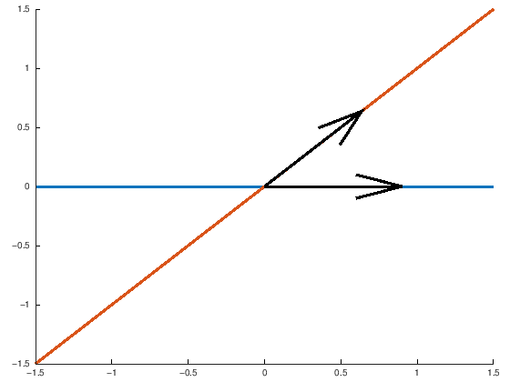

```matlab
#3. Dessiner les droites correspondants aux vecteurs propres et le sense des trajectoires associés
line_range = -1.5:.1:1.5;
line_1 = (V(2,1)/V(1,1)) * line_range;
line_2 = (V(2,2)/V(1,2)) * line_range;
hold on;
plot(line_range,line_1,"linewidth",10);
plot(line_range,line_2,"linewidth",10);
quiver([0;0],[0;0],V(1,:),V(2,:),"linewidth",10,"color","k")
```

```matlab
# 4.b Dessiner les vecteurs vitesse pour les points suivants (en normalisant leurs tailles) $(0,1),(1,0),(0,-1),(-1,0),(-0.5,-1)$
point_sequence = [[0,1];[0,-1];[1,0];[-1,0]]'; #cbind like
velocity_sequence = [];
for point_vec = point_sequence # Column-wise iteration
    velocity_vec = A*point_vec
    velocity_norm = velocity_vec/norm(velocity_vec);
    velocity_sequence = [velocity_sequence,velocity_norm];
endfor
```

```
velocity_vec =

   1
   1

velocity_vec =

  -1
  -1

velocity_vec =

   0
   0

warning: division by zero
velocity_vec =

   0
   0

warning: division by zero
```

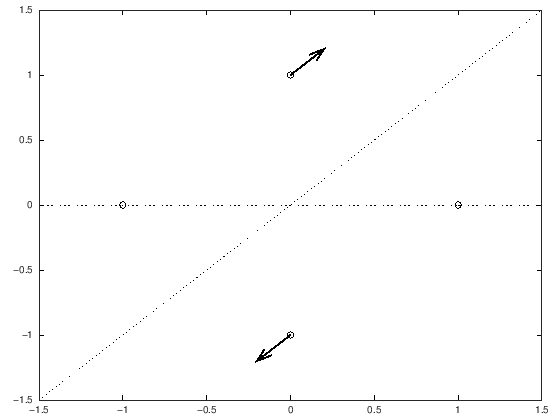

```matlab
quiver(point_sequence(1,:),point_sequence(2,:),velocity_sequence(1,:),velocity_sequence(2,:),0.2,"linewidth",5,"color","k");
hold on;
plot(point_sequence(1,:),point_sequence(2,:),"ok")
plot(line_range,line_1,"linestyle",":","color","k");
plot(line_range,line_2,"linestyle",":","color","k");
```

```matlab
# Define grid for plotting
x1range=-1.5:.1:1.5;
x2range=-1.5:.1:1.5;
[x1,x2] = meshgrid(x1range, x2range);

# Define the system to plot (based on matrix A)
x1p = A(1,1)*x1+A(1,2)*x2;
x2p = A(2,1)*x1+A(2,2)*x2;

#Normalize values for plotting
arrow=sqrt(x1p.^2+x2p.^2);
```

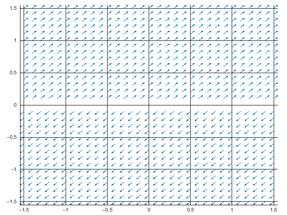

```matlab
# Vector field plot
hold on;
quiver(x1,x2,x1p./arrow,x2p./arrow,0.5);
# Trajectory plot
#sys_str = sprintf('[%d*x(1)+%d*x(2);%d*x(1)+%d*x(2)]',A(1,1),A(1,2),A(2,1),A(2,2))
#sys_ode = inline(sys_str,'t','x')
#for x_0=0:0.1:1
# [ts,ys] = ode45(sys_ode,[0,10],[0;x_0]);
# plot(ys(:,1),ys(:,2))
#end
grid on;
axis tight;
```

```matlab
pkg load symbolic
syms x1(t) x2(t);
ode_sys = [diff(x1(t),t) == A(1,1)*x1(t) + A(1,2)*x2(t);  diff(x2(t),t) == A(2,1)*x1(t) + A(2,2)*x2(t)]
solutions = dsolve(ode_sys);
solutions{1}
solutions{2}
```

```
ode_sys = (sym 2x1 matrix)

  [d                ]
  [--(x1(t)) = x2(t)]
  [dt               ]
  [                 ]
  [d                ]
  [--(x2(t)) = x2(t)]
  [dt               ]

ans = (sym)

              t
  x1(t) = C1*e  + C2

ans = (sym)

              t
  x2(t) = C1*e
```

# Exercice 2 - Valeurs propres complexes

$ \mathbf{A} = \begin{bmatrix} 0 & -1 \\ 1 & 0 \end{bmatrix} $

1. Calculer les valeurs propres et vecteurs propres et en déduire le type du système
2. Vérifier le lien entre la trace et le déterminant de la matrice
3. Dessiner les vecteurs vitesse pour les points suivants (en normalisant leurs tailles):
   - $(0,1),(0,-1),(1,0),(-1,0)$

```matlab
# 1. - Calcul valeur propres et vecteurs propres
A = [0 -1; 1 0]
[V,L] = eig(A)
```

```
A =

   0  -1
   1   0

V =

   0.70711 + 0.00000i   0.70711 - 0.00000i
   0.00000 - 0.70711i   0.00000 + 0.70711i

L =

Diagonal Matrix

   0 + 1i        0
        0   0 - 1i
```

```matlab
printf("Tr(A) = %d\n",trace(A));
printf("det(A) = %d\n",det(A));
printf("Tr(A) > 4*det(A)? = %d\n",(trace(A) > 4*det(A)));
```

```
Tr(A) = 0
det(A) = 1
Tr(A) > 4*det(A)? = 0
```

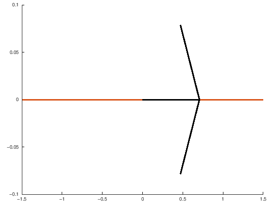

```matlab
#3. Dessiner les droites correspondants aux vecteurs propres et le sense des trajectoires associés
line_range = -1.5:.1:1.5;
line_1 = (V(2,1)/V(1,1)) * line_range;
line_2 = (V(2,2)/V(1,2)) * line_range;
hold on;
plot(line_range,line_1,"linewidth",10);
plot(line_range,line_2,"linewidth",10);
quiver([0;0],[0;0],V(1,:),V(2,:),"linewidth",10,"color","k")
```

```matlab
# 4.b Dessiner les vecteurs vitesse pour les points suivants (en normalisant leurs tailles) $(0,1),(1,0),(0,-1),(-1,0),(-0.5,-1)$
point_sequence = [[0,1];[0,-1];[1,0];[-1,0]]'; #cbind like
velocity_sequence = [];
for point_vec = point_sequence # Column-wise iteration
    velocity_vec = A*point_vec
    velocity_norm = velocity_vec/norm(velocity_vec);
    velocity_sequence = [velocity_sequence,velocity_norm];
endfor
```

```
velocity_vec =

  -1
   0

velocity_vec =

   1
   0

velocity_vec =

   0
   1

velocity_vec =

   0
  -1
```

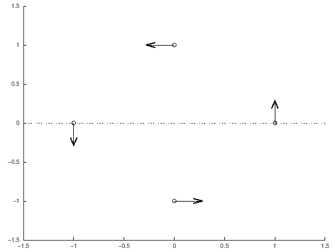

```matlab
hold on;
quiver(point_sequence(1,:),point_sequence(2,:),velocity_sequence(1,:),velocity_sequence(2,:),0.2,"linewidth",5,"color","k");
plot(point_sequence(1,:),point_sequence(2,:),"ok");
plot(line_range,line_1,"linestyle",":","color","k");
plot(line_range,line_2,"linestyle",":","color","k");
```

```matlab
# Define grid for plotting
x1range=-3:.1:3;
x2range=-3:.1:3;
[x1,x2] = meshgrid(x1range, x2range);

# Define the system to plot (based on matrix A)
x1p = A(1,1)*x1+A(1,2)*x2;
x2p = A(2,1)*x1+A(2,2)*x2;

#Normalize values for plotting
arrow=sqrt(x1p.^2+x2p.^2);
```

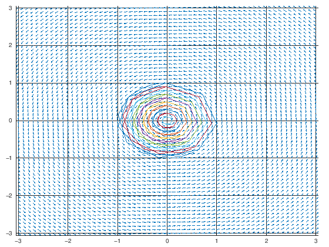

```matlab
# Vector field plot
hold on;
quiver(x1,x2,x1p./arrow,x2p./arrow,0.5);
# Trajectory plot
sys_str = sprintf('[%d*x(1)+%d*x(2);%d*x(1)+%d*x(2)]',A(1,1),A(1,2),A(2,1),A(2,2));
sys_ode = inline(sys_str,'t','x');
for x_0=0:0.1:1
 [ts,ys] = ode45(sys_ode,[0,10],[0;x_0]);
 plot(ys(:,1),ys(:,2))
end
grid on;
axis tight;
```

```matlab
pkg load symbolic
syms x1(t) x2(t);
ode_sys = [diff(x1(t),t) == A(1,1)*x1(t) + A(1,2)*x2(t);  diff(x2(t),t) == A(2,1)*x1(t) + A(2,2)*x2(t)]
solutions = dsolve(ode_sys);
solutions{1}
solutions{2}
```

```
ode_sys = (sym 2x1 matrix)

  [d                 ]
  [--(x1(t)) = -x2(t)]
  [dt                ]
  [                  ]
  [d                 ]
  [--(x2(t)) = x1(t) ]
  [dt                ]

ans = (sym) x1(t) = -C1*cos(t) - C2*sin(t)
ans = (sym) x2(t) = -C1*sin(t) + C2*cos(t)
```

# Exercice 3 - Valeurs propres complexes

$ \mathbf{A} = \begin{bmatrix} \frac{1}{3} & -2 \\ 3 & -1 \end{bmatrix} $

1. Calculer les valeurs propres et vecteurs propres et en déduire le type du système
2. Vérifier le lien entre la trace et le déterminant de la matrice
3. Dessiner les vecteurs vitesse pour les points suivants (en normalisant leurs tailles):
   - $(0,1),(0,-1),(1,0),(-1,0)$

```matlab
# 1. - Calcul valeur propres et vecteurs propres
A = [1/3 -2; 3 -1]
[V,L] = eig(A)
```

```
A =

   0.33333  -2.00000
   3.00000  -1.00000

V =

   0.17213 + 0.60858i   0.17213 - 0.60858i
   0.77460 + 0.00000i   0.77460 - 0.00000i

L =

Diagonal Matrix

  -0.3333 + 2.3570i                  0
                  0  -0.3333 - 2.3570i
```

```matlab
printf("Tr(A) = %d\n",trace(A));
printf("det(A) = %d\n",det(A));
printf("Tr(A) > 4*det(A)? = %d\n",(trace(A) > 4*det(A)));
```

```
Tr(A) = -0.666667
det(A) = 5.66667
Tr(A) > 4*det(A)? = 0
```

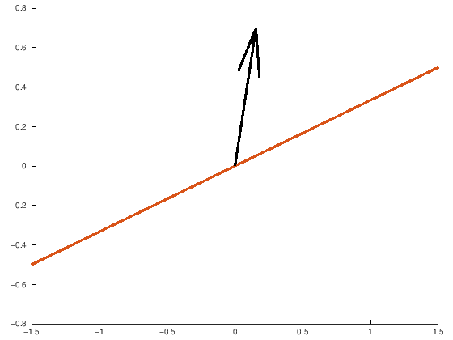

```matlab
#3. Dessiner les droites correspondants aux vecteurs propres et le sense des trajectoires associés
line_range = -1.5:.1:1.5;
line_1 = (V(2,1)/V(1,1)) * line_range;
line_2 = (V(2,2)/V(1,2)) * line_range;
hold on;
plot(line_range,line_1,"linewidth",10);
plot(line_range,line_2,"linewidth",10);
quiver([0;0],[0;0],V(1,:),V(2,:),"linewidth",10,"color","k")
```

```matlab
# 4.b Dessiner les vecteurs vitesses pour les points suivants (en normalisant leurs tailles) $(0,1),(1,0),(0,-1),(-1,0),(-0.5,-1)$
point_sequence = [[0,1];[0,-1];[1,0];[-1,0]]'; #cbind like
velocity_sequence = [];
for point_vec = point_sequence # Column-wise iteration
    velocity_vec = A*point_vec
    velocity_norm = velocity_vec/norm(velocity_vec);
    velocity_sequence = [velocity_sequence,velocity_norm];
endfor
```

```
velocity_vec =

  -2
  -1

velocity_vec =

   2
   1

velocity_vec =

   0.33333
   3.00000

velocity_vec =

  -0.33333
  -3.00000
```

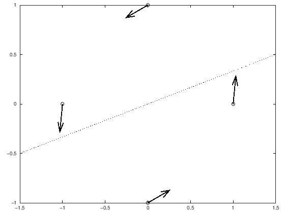

```matlab
quiver(point_sequence(1,:),point_sequence(2,:),velocity_sequence(1,:),velocity_sequence(2,:),0.2,"linewidth",5,"color","k");
hold on;
plot(point_sequence(1,:),point_sequence(2,:),"ok")
plot(line_range,line_1,"linestyle",":","color","k");
plot(line_range,line_2,"linestyle",":","color","k");
```

```matlab
# Define grid for plotting
x1range=-1.5:.1:1.5;
x2range=-1.5:.1:1.5;
[x1,x2] = meshgrid(x1range, x2range);

# Define the system to plot (based on matrix A)
x1p = A(1,1)*x1+A(1,2)*x2;
x2p = A(2,1)*x1+A(2,2)*x2;

#Normalize values for plotting
arrow=sqrt(x1p.^2+x2p.^2);
```

```
sys_str = [0.333333*x(1)+-2*x(2);3*x(1)+-1*x(2)]
sys_ode = f(t, x) = [0.333333*x(1)+-2*x(2);3*x(1)+-1*x(2)]
```

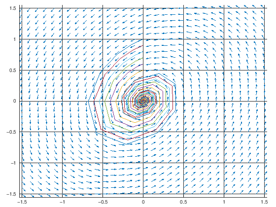

```matlab
# Vector field plot
hold on;
quiver(x1,x2,x1p./arrow,x2p./arrow,0.5);
# Trajectory plot
sys_str = sprintf('[%d*x(1)+%d*x(2);%d*x(1)+%d*x(2)]',A(1,1),A(1,2),A(2,1),A(2,2))
sys_ode = inline(sys_str,'t','x')
for x_0=0:0.1:1
 [ts,ys] = ode45(sys_ode,[0,10],[0;x_0]);
 plot(ys(:,1),ys(:,2))
end
grid on;
axis tight;
```

```matlab
pkg load symbolic
syms x1(t) x2(t);
ode_sys = [diff(x1(t),t) == A(1,1)*x1(t) + A(1,2)*x2(t);  diff(x2(t),t) == A(2,1)*x1(t) + A(2,2)*x2(t)]
solutions = dsolve(ode_sys);
solutions{1}
solutions{2}
```

```
warning: passing floating-point values to sym is dangerous, see "help sym"
warning: called from
    double_to_sym_heuristic at line 50 column 7
    sym at line 379 column 13
    mtimes at line 65 column 5
ode_sys = (sym 2x1 matrix)

  [d           x1(t)          ]
  [--(x1(t)) = ----- - 2*x2(t)]
  [dt            3            ]
  [                           ]
  [d                          ]
  [--(x2(t)) = 3*x1(t) - x2(t)]
  [dt                         ]

ans = (sym)

                                                         -t
          /          /    ___  \           /    ___  \\  ---
          |          |5*\/ 2 *t|           |5*\/ 2 *t||   3
  x1(t) = |- 2*C1*cos|---------| - 2*C2*sin|---------||*e
          \          \    3    /           \    3    //

ans = (sym)

          /   /             /    ___  \        /    ___  \\      /       /    __
          |   |      ___    |5*\/ 2 *t|        |5*\/ 2 *t||      |       |5*\/ 2
          |   |  5*\/ 2 *sin|---------|   2*cos|---------||      |  2*sin|------
          |   |             \    3    /        \    3    /|      |       \    3
  x2(t) = |C1*|- ---------------------- - ----------------| + C2*|- ------------
          \   \            3                     3        /      \         3

  _  \              /    ___  \\\
   *t|       ___    |5*\/ 2 *t|||  -t
  ---|   5*\/ 2 *cos|---------|||  ---
     /              \    3    /||   3
  ---- + ----------------------||*e
                   3           //
```